# Data Crafters_EDA

- I. Introduction
- II. Description of the data
- III. Exploring EDA Questions
- 1. Importing Packages
- 2. Reading Data
- 3. Summarizing & Understading the Data
  - 3.1 Removing 1st column from both the dataframes named 'Unnamed:0'
  - 3.2 Checking the shape of both the dataframes
  - 3.3 Obtaining description of the data in the datafame
  - 3.4 Identified Zero Variance Variables
  - 3.5 Checking the shape of q_data after columns drop
  - 3.6 Finding NA and Categorical Values in Qualitative Dataframe (q_data))
  - 3.6.1 Replacing NA values with None
  - 3.6.2 Factorizing the Categorical columns
  - 3.7 Finding NA and Categorical Values in Time Series Dataframe (t_data))
  - 3.8 Extracting Year, Month and Date from Calendar_day_date
- 4. Analysis On Qualitative and Time Series Data
  - 4.1 Analysing the 4 target variables(In-Store, Food, Diesel, Unleaded))
    - 4.1.1.Plotting diesel and unleaded sales on Days of the week for the year 2021,2022 and 2023
    - 4.1.2 Plotting Inside and Food sales on Days of the week for the year 2021,2022 and 2023
    - 4.1.3 Sales of all target variables based on Calender Week
    - 4.1.4 Identifying Sale of Diesel and Unleaded during Weekend and Weekdays of the years 2021, 2022, 2023
    - 4.1.5 Identifying Sale of Merchandise and Food during Weekend and Weekdays for the years 2021,2022,2023
    - 4.1.6 Plotting diesel and unleaded sales on Holidays for the year 2021,2022 and 2023
    - 4.1.7 Plotting in store and food sales on Holidays for the year 2021,2022 and 2023
    - 4.1.8 Plotting In Store and food sales of Maverik store during each month of the year 2021,2022 and 2023
    - 4.1.9 Plotting Diesel and Unleaded sales of Maverik store during each month of the year 2021,2022 and 2023
  - 4.2.0 Inside and Food Sales based on Seasonality
    - 4.2.1 Diesel and Unleaded Sales based on Seasonality
    - 4.2.2 Total sale of target variables for all site id's
- 5. Merging both dataframes
  - 5.1 Relation between customer population and income
  - 5.2 Population in Miles vs Total Sales
  - 5.3 Customer Income vs Total Sales
  - 5.4 Distribution of Sales based on Stores that Sell "freal," "bonfire_grill," "pizza," and "cinnabon"
  - 5.5 Comparing Sale of Diesel and Unleaded based on Fuel Station Features
  - 5.6 Comparing Sale of Diesel based on Fuel Station Features
  - 5.7 Comparing Sale of Unleaded based on Fuel Station Features
- IV. Results
- V. Contributions

## I. Introduction

### Maverik faces a challenge in crafting comprehensive ROI documents for new store openings due to the difficulty in accurately forecasting their first-year sales. This challenge hampers strategic financial planning and decision-making, impacting the company's ability to grow sustainably. The analytic problem at hand involves developing a predictive model that can provide accurate daily forecasts for merchandise, food sales, unleaded, and diesel sales for new Maverik stores in their first year.

### The purpose of the Exploratory Data Analysis (EDA) notebook is to thoroughly examine and understand the provided dataset, identify patterns, trends, and potential outliers, and prepare the data for the predictive modeling phase. It serves as the foundational step in the project, helping us to gain insights into the data's characteristics, distribution, and relationships between variables.

### In the EDA notebook, we will explore questions about the data, such as:

### 1. What are the target variables?

### 2. If there are any zero variance variables present in the data?

### 3. If there are any NA values that are required to be handled?

### 4. If there are categorical variables that require transformation to numerical values?

### 5. What is the mean sales performance of the target variables across various time intervals, including weekly, during holidays, monthly, by day of the week, annually, on weekdays, weekends, and across various sites?

### 6. What are the key features in the dataset related to new store openings and sales performance?

### 7. Do noticeable patterns or fluctuations in sales exist across different seasons throughout the year?

### 8. Does the count of the population, the distance of the store from the population, and their income significantly influence sales?

### 9. What are the features of the fuel station that can impact the sales of the store?

### 10. What in-store attributes or food items can enhance sales performance?

### 11. What are the distributions of key variables, and do they exhibit any correlations?

### 12. What initial insights can be gained from the data that might inform the modeling process?

## II. Description of the data

### We have two datasets: one is a time series dataset, and the other is a qualitative dataset. Each dataset contains various columns and we have used these for the EDA below.

### The time series dataset includes information about store openings, dates, sales data, and fuel-related metrics. It is likely suitable for analyzing trends over time.

### The qualitative dataset provides information about various attributes of the sites, such as square footage, available services (e.g., car wash, electric vehicle charging), and demographic data for different radiuses around the site.

### A detailed demonstration and analytics of all the columns have been performed below.

## III. Exploring EDA Questions

## 1. Importing Packages

```python
import numpy as np
import pandas as pd
import seaborn as sns
import warnings
warnings.filterwarnings("ignore")
import matplotlib.pyplot as plt
from pandas.plotting import table
import plotly.express as px
import matplotlib.ticker as mtick
```

```python
import plotly.io as pio
pio.renderers.default = 'notebook_connected'
```

## 2. Reading Data

```python
q_data= pd.read_csv("qualitative_data_msba.csv")
t_data=pd.read_csv("time_series_data_msba.csv")
```

## 3. Summarizing & Understading the Data

```python
q_data.head()
```

|  | Unnamed: 0 | open_year | square_feet | front_door_count | years_since_last_project | parking_spaces | lottery | freal | bonfire_grill | pizza | ... | rv_lanes_fueling_positions_2 | hi_flow_rv_lanes_layout | hi_flow_rv_lanes_stack_type | non_24_hour | self_check_out | mens_toilet_count | mens_urinal_count | womens_toilet_count | womens_sink_count | site_id_msba |
| --- | --- | --- | --- | --- | --- | --- | --- | --- | --- | --- | --- | --- | --- | --- | --- | --- | --- | --- | --- | --- | --- |
| 0 | 1 | 2021 | 5046 | 2 | 2 | 38 | Yes | Yes | Yes | No | ... | 6 | Stack | HF/RV | No | Yes | 2 | 2 | 6 | 2 | 21560 |
| 1 | 2 | 2021 | 5046 | 2 | 2 | 39 | No | Yes | Yes | Yes | ... | 4 | Combo | HF/RV | No | Yes | 5 | 5 | 10 | 4 | 21980 |
| 2 | 3 | 2021 | 5046 | 2 | 2 | 35 | Yes | Yes | Yes | Yes | ... | 5 | In-Line | None | No | Yes | 3 | 2 | 4 | 1 | 22015 |
| 3 | 4 | 2021 | 5046 | 2 | 2 | 36 | No | Yes | Yes | Yes | ... | 4 | Combo | HF/RV | No | Yes | 3 | 3 | 6 | 2 | 22085 |
| 4 | 5 | 2021 | 5046 | 2 | 2 | 25 | Yes | Yes | Yes | No | ... | 0 | NaN | NaN | No | Yes | 0 | 0 | 0 | 0 | 22120 |

5 rows × 55 columns

```python
t_data.head()
```

|  | Unnamed: 0 | capital_projects.soft_opening_date | calendar.calendar_day_date | calendar.fiscal_week_id_for_year | calendar.day_of_week | calendar_information.holiday | calendar_information.type_of_day | daily_yoy_ndt.total_inside_sales | daily_yoy_ndt.total_food_service | diesel | unleaded | site_id_msba |
| --- | --- | --- | --- | --- | --- | --- | --- | --- | --- | --- | --- | --- |
| 0 | 1 | 2022-06-14 | 2022-06-17 | 25 | Friday | NONE | WEEKDAY | 2168.2920 | 861.6930 | 722.7745 | 1425.1020 | 24535 |
| 1 | 2 | 2022-06-14 | 2022-06-22 | 25 | Wednesday | NONE | WEEKDAY | 2051.5635 | 808.0275 | 730.4850 | 1436.2740 | 24535 |
| 2 | 3 | 2022-06-14 | 2022-06-23 | 25 | Thursday | NONE | WEEKDAY | 2257.5000 | 966.4410 | 895.7970 | 1594.3725 | 24535 |
| 3 | 4 | 2022-06-14 | 2022-06-26 | 26 | Sunday | NONE | WEEKEND | 1520.5925 | 542.3250 | 584.2900 | 1124.9280 | 24535 |
| 4 | 5 | 2022-06-14 | 2022-06-27 | 26 | Monday | NONE | WEEKDAY | 1897.6930 | 771.4525 | 852.2605 | 1640.2540 | 24535 |

### 3.1. Removing 1st column from both the dataframes named 'Unnamed: 0'

```python
q_data= q_data.drop("Unnamed: 0", axis=1)
t_data= t_data.drop("Unnamed: 0", axis=1)
```

```python
q_data.head()
```

|  | open_year | square_feet | front_door_count | years_since_last_project | parking_spaces | lottery | freal | bonfire_grill | pizza | cinnabon | ... | rv_lanes_fueling_positions_2 | hi_flow_rv_lanes_layout | hi_flow_rv_lanes_stack_type | non_24_hour | self_check_out | mens_toilet_count | mens_urinal_count | womens_toilet_count | womens_sink_count | site_id_msba |
| --- | --- | --- | --- | --- | --- | --- | --- | --- | --- | --- | --- | --- | --- | --- | --- | --- | --- | --- | --- | --- | --- |
| 0 | 2021 | 5046 | 2 | 2 | 38 | Yes | Yes | Yes | No | No | ... | 6 | Stack | HF/RV | No | Yes | 2 | 2 | 6 | 2 | 21560 |
| 1 | 2021 | 5046 | 2 | 2 | 39 | No | Yes | Yes | Yes | No | ... | 4 | Combo | HF/RV | No | Yes | 5 | 5 | 10 | 4 | 21980 |
| 2 | 2021 | 5046 | 2 | 2 | 35 | Yes | Yes | Yes | Yes | No | ... | 5 | In-Line | None | No | Yes | 3 | 2 | 4 | 1 | 22015 |
| 3 | 2021 | 5046 | 2 | 2 | 36 | No | Yes | Yes | Yes | No | ... | 4 | Combo | HF/RV | No | Yes | 3 | 3 | 6 | 2 | 22085 |
| 4 | 2021 | 5046 | 2 | 2 | 25 | Yes | Yes | Yes | No | No | ... | 0 | NaN | NaN | No | Yes | 0 | 0 | 0 | 0 | 22120 |

5 rows × 54 columns

```python
t_data.head()
```

|  | capital_projects.soft_opening_date | calendar.calendar_day_date | calendar.fiscal_week_id_for_year | calendar.day_of_week | calendar_information.holiday | calendar_information.type_of_day | daily_yoy_ndt.total_inside_sales | daily_yoy_ndt.total_food_service | diesel | unleaded | site_id_msba |
| --- | --- | --- | --- | --- | --- | --- | --- | --- | --- | --- | --- |
| 0 | 2022-06-14 | 2022-06-17 | 25 | Friday | NONE | WEEKDAY | 2168.2920 | 861.6930 | 722.7745 | 1425.1020 | 24535 |
| 1 | 2022-06-14 | 2022-06-22 | 25 | Wednesday | NONE | WEEKDAY | 2051.5635 | 808.0275 | 730.4850 | 1436.2740 | 24535 |
| 2 | 2022-06-14 | 2022-06-23 | 25 | Thursday | NONE | WEEKDAY | 2257.5000 | 966.4410 | 895.7970 | 1594.3725 | 24535 |
| 3 | 2022-06-14 | 2022-06-26 | 26 | Sunday | NONE | WEEKEND | 1520.5925 | 542.3250 | 584.2900 | 1124.9280 | 24535 |
| 4 | 2022-06-14 | 2022-06-27 | 26 | Monday | NONE | WEEKDAY | 1897.6930 | 771.4525 | 852.2605 | 1640.2540 | 24535 |

### 3.2 Checking the shape of both the dataframes

```python
q_data.shape
```

```
(37, 54)
```

```python
t_data.shape
```

```
(13908, 11)
```

### 3.3 Obtaining description of the data in the datafame

```python
q_data[['square_feet','x1_mile_pop','x1_mile_emp','x1_mile_income','x1_2_mile_pop','x1_2_mile_emp']].describe()
```

|  | square_feet | x1_mile_pop | x1_mile_emp | x1_mile_income | x1_2_mile_pop | x1_2_mile_emp |
| --- | --- | --- | --- | --- | --- | --- |
| count | 37.00000 | 37.000000 | 37.000000 | 37.000000 | 37.000000 | 37.000000 |
| mean | 4970.27027 | 6703.567568 | 4757.648649 | 53300.378378 | 1833.108108 | 1514.135135 |
| std | 575.93121 | 5694.011350 | 4697.168291 | 24333.027254 | 1915.140476 | 2489.423094 |
| min | 2933.00000 | 0.000000 | 56.000000 | 0.000000 | 0.000000 | 31.000000 |
| 25% | 5046.00000 | 1984.000000 | 1771.000000 | 39538.000000 | 262.000000 | 386.000000 |
| 50% | 5046.00000 | 5574.000000 | 3895.000000 | 46356.000000 | 1003.000000 | 1037.000000 |
| 75% | 5046.00000 | 11269.000000 | 6002.000000 | 73519.000000 | 2686.000000 | 1616.000000 |
| max | 6134.00000 | 18692.000000 | 26077.000000 | 110957.000000 | 5923.000000 | 15403.000000 |

```python
t_data[['daily_yoy_ndt.total_inside_sales', 'daily_yoy_ndt.total_food_service', 'diesel', 'unleaded']].describe()
```

|  | daily_yoy_ndt.total_inside_sales | daily_yoy_ndt.total_food_service | diesel | unleaded |
| --- | --- | --- | --- | --- |
| count | 13908.000000 | 13908.000000 | 13908.000000 | 13908.000000 |
| mean | 2846.537988 | 759.922326 | 1702.585227 | 2382.091588 |
| std | 981.299870 | 341.578220 | 2161.208192 | 1025.518658 |
| min | 0.000000 | 0.000000 | 0.000000 | 240.180500 |
| 25% | 2181.156250 | 521.087875 | 383.062750 | 1654.149000 |
| 50% | 2693.976250 | 697.434500 | 1018.920000 | 2256.677500 |
| 75% | 3325.306250 | 924.282625 | 2283.297625 | 2928.254000 |
| max | 7172.466000 | 2531.662000 | 20853.952000 | 8077.233500 |

### 3.4 Identified Zero Variance Variables

#### The following columns exhibit consistent values throughout and do not demonstrate significant correlation with the target variables. Therefore, they can be considered as zero variance variables and may be removed from the dataset:

#### 1. front_door_count

#### 2. godfather_s_pizza

#### 3. diesel

#### 4. car_wash

#### 5. ev_charging

#### 6. non_24_hour

#### 7. self_check_out

```python
q_data.drop(['front_door_count','godfather_s_pizza','car_wash','ev_charging','non_24_hour','self_check_out','diesel'], axis=1,inplace=True)
```

### 3.5 Checking the shape of q_data after columns drop

```python
q_data.shape
```

```
(37, 47)
```

### 3.6 Finding NA and Categorical Values in Qualitative Dataframe (q_data)

```python
na_values = q_data.isna().sum()
na_values[na_values > 0]
```

```
rv_lanes_layout                14
rv_lanes_stack_type            14
hi_flow_lanes_layout           15
hi_flow_lanes_stack_type       15
hi_flow_rv_lanes_layout        14
hi_flow_rv_lanes_stack_type    14
dtype: int64
```

##### As per the above result, 6 columns of qualitative dataframe has N/A value. It means that Maverik does not provide these features in few of it stores.

```python
cat_col= q_data.select_dtypes(include="object").columns.tolist()
cat_col
```

```
['lottery',
 'freal',
 'bonfire_grill',
 'pizza',
 'cinnabon',
 'ethanol_free',
 'hi_flow_lanes',
 'rv_lanes',
 'hi_flow_rv_lanes',
 'def',
 'cat_scales',
 'rv_dumps',
 'propane',
 'traditional_forecourt_layout',
 'traditional_forecourt_stack_type',
 'rv_lanes_layout',
 'rv_lanes_stack_type',
 'hi_flow_lanes_layout',
 'hi_flow_lanes_stack_type',
 'hi_flow_rv_lanes_layout',
 'hi_flow_rv_lanes_stack_type']
```

### 3.6.1 Replacing NA values with None

```python
columns_with_na = q_data.columns[q_data.isna().any()].tolist()

for column in columns_with_na:
    mode_value = q_data[column].mode()[0]
    q_data[column].fillna("None", inplace=True)
```

### 3.6.2 Factorizing the Categorical columns

```python
for column in cat_col:
    q_data[column] = pd.factorize(q_data[column])[0]
```

```python
import pandas as pd

# Define bins and labels
bins = [20, 30, 40, 50]
labels = [1, 2, 3]

# Bin the values in the 'parking_spaces' column
q_data['parking_spaces'] = pd.cut(q_data['parking_spaces'], bins=bins, labels=labels, include_lowest=True).astype(int)
```

```python
q_data.head()
```

|  | open_year | square_feet | years_since_last_project | parking_spaces | lottery | freal | bonfire_grill | pizza | cinnabon | ethanol_free | ... | hi_flow_lanes_stack_type | hi_flow_lanes_fueling_positions_2 | rv_lanes_fueling_positions_2 | hi_flow_rv_lanes_layout | hi_flow_rv_lanes_stack_type | mens_toilet_count | mens_urinal_count | womens_toilet_count | womens_sink_count | site_id_msba |
| --- | --- | --- | --- | --- | --- | --- | --- | --- | --- | --- | --- | --- | --- | --- | --- | --- | --- | --- | --- | --- | --- |
| 0 | 2021 | 5046 | 2 | 2 | 0 | 0 | 0 | 0 | 0 | 0 | ... | 0 | 4 | 6 | 0 | 0 | 2 | 2 | 6 | 2 | 21560 |
| 1 | 2021 | 5046 | 2 | 2 | 1 | 0 | 0 | 1 | 0 | 1 | ... | 0 | 9 | 4 | 1 | 0 | 5 | 5 | 10 | 4 | 21980 |
| 2 | 2021 | 5046 | 2 | 2 | 0 | 0 | 0 | 1 | 0 | 0 | ... | 1 | 0 | 5 | 2 | 1 | 3 | 2 | 4 | 1 | 22015 |
| 3 | 2021 | 5046 | 2 | 2 | 1 | 0 | 0 | 1 | 0 | 0 | ... | 0 | 5 | 4 | 1 | 0 | 3 | 3 | 6 | 2 | 22085 |
| 4 | 2021 | 5046 | 2 | 1 | 0 | 0 | 0 | 0 | 0 | 1 | ... | 1 | 0 | 0 | 3 | 1 | 0 | 0 | 0 | 0 | 22120 |

5 rows × 47 columns

### 3.7 Finding NA and Categorical Values in Time Series Dataframe (t_data)

```python
na_values = t_data.isna().sum()
na_values[na_values > 0]
```

```
Series([], dtype: int64)
```

#### There are no columns in time series data that has N/A value

### 3.8 Extracting Year, Month and Date from Calendar_day_date

```python
t_data['calendar.calendar_day_date'] = pd.to_datetime(t_data['calendar.calendar_day_date'])

t_data['calendar_year'] = t_data['calendar.calendar_day_date'].dt.year
t_data['calendar_month'] = t_data['calendar.calendar_day_date'].dt.month
t_data['calendar_day'] = t_data['calendar.calendar_day_date'].dt.day
```

```python
t_data.head()
```

|  | capital_projects.soft_opening_date | calendar.calendar_day_date | calendar.fiscal_week_id_for_year | calendar.day_of_week | calendar_information.holiday | calendar_information.type_of_day | daily_yoy_ndt.total_inside_sales | daily_yoy_ndt.total_food_service | diesel | unleaded | site_id_msba | calendar_year | calendar_month | calendar_day |
| --- | --- | --- | --- | --- | --- | --- | --- | --- | --- | --- | --- | --- | --- | --- |
| 0 | 2022-06-14 | 2022-06-17 | 25 | Friday | NONE | WEEKDAY | 2168.2920 | 861.6930 | 722.7745 | 1425.1020 | 24535 | 2022 | 6 | 17 |
| 1 | 2022-06-14 | 2022-06-22 | 25 | Wednesday | NONE | WEEKDAY | 2051.5635 | 808.0275 | 730.4850 | 1436.2740 | 24535 | 2022 | 6 | 22 |
| 2 | 2022-06-14 | 2022-06-23 | 25 | Thursday | NONE | WEEKDAY | 2257.5000 | 966.4410 | 895.7970 | 1594.3725 | 24535 | 2022 | 6 | 23 |
| 3 | 2022-06-14 | 2022-06-26 | 26 | Sunday | NONE | WEEKEND | 1520.5925 | 542.3250 | 584.2900 | 1124.9280 | 24535 | 2022 | 6 | 26 |
| 4 | 2022-06-14 | 2022-06-27 | 26 | Monday | NONE | WEEKDAY | 1897.6930 | 771.4525 | 852.2605 | 1640.2540 | 24535 | 2022 | 6 | 27 |

## 4. Analysis On Qualitative and Time Series Data

### 4.1 Analysing the 4 target variables(In-Store, Food, Diesel, Unleaded)

#### 4.1.1 Plotting diesel and unleaded sales on Days of the week for the year 2021,2022 and 2023

```python
t_data['calendar.calendar_day_date'] = pd.to_datetime(t_data['calendar.calendar_day_date'])

t_data.set_index('calendar.calendar_day_date', inplace=True)
```

##### Use the slider to drill through year,month,date and time

```python
average_diesel_sales = t_data.groupby(t_data.index)['diesel'].mean()
average_unleaded_sales = t_data.groupby(t_data.index)['unleaded'].mean()


average_sales_df = pd.DataFrame({'Diesel': average_diesel_sales, 'Unleaded': average_unleaded_sales})


fig = px.line(average_sales_df, x=average_sales_df.index, y=average_sales_df.columns,
              title='Average Diesel and Unleaded Sales Over Time')
fig.update_xaxes(title='Date', rangeslider_visible=True)
fig.update_yaxes(title='Average Sales')
fig.show()
```

[interactive chart not shown]

### 4.1.2 Plotting Inside and Food sales on Days of the week for the year 2021,2022 and 2023

```python
average_inside_sales = t_data.groupby(t_data.index)['daily_yoy_ndt.total_inside_sales'].mean()
average_food_sales = t_data.groupby(t_data.index)['daily_yoy_ndt.total_food_service'].mean()


average_sales_df = pd.DataFrame({'daily_yoy_ndt.total_inside_sales': average_inside_sales, 'daily_yoy_ndt.total_food_service': average_food_sales})


fig = px.line(average_sales_df, x=average_sales_df.index, y=average_sales_df.columns,
              title='Average Inside and Food Sales Over Time')
fig.update_xaxes(title='Date', rangeslider_visible=True)
fig.update_yaxes(title='Average Sales')
fig.show()
```

[interactive chart not shown]

### 4.1.3 Sales of all target variables based on Calender Week

```python
t_data['calendar.fiscal_week_id_for_year'].min(), t_data['calendar.fiscal_week_id_for_year'].max()
```

```
(1, 52)
```

```python
df_time_aggregate = t_data.groupby('calendar.fiscal_week_id_for_year')['daily_yoy_ndt.total_inside_sales', 'daily_yoy_ndt.total_food_service', 'diesel', 'unleaded'].sum().reset_index()
```

##### Lets check if we have more than one sales data for a date

```python
temp = t_data.groupby('calendar.fiscal_week_id_for_year')['daily_yoy_ndt.total_inside_sales'].size()
temp[temp > 1].sort_values(ascending=False)
```

```
calendar.fiscal_week_id_for_year
20    273
38    270
13    270
33    270
28    270
24    270
21    270
49    270
45    270
19    269
11    268
46    268
39    268
32    268
```

[output cut: 39 more lines]

##### Indexing with Time Series Data

```python
df_time_aggregate = df_time_aggregate.set_index('calendar.fiscal_week_id_for_year')
df_time_aggregate.index
```

```
Int64Index([ 1,  2,  3,  4,  5,  6,  7,  8,  9, 10, 11, 12, 13, 14, 15, 16, 17,
            18, 19, 20, 21, 22, 23, 24, 25, 26, 27, 28, 29, 30, 31, 32, 33, 34,
            35, 36, 37, 38, 39, 40, 41, 42, 43, 44, 45, 46, 47, 48, 49, 50, 51,
            52],
           dtype='int64', name='calendar.fiscal_week_id_for_year')
```

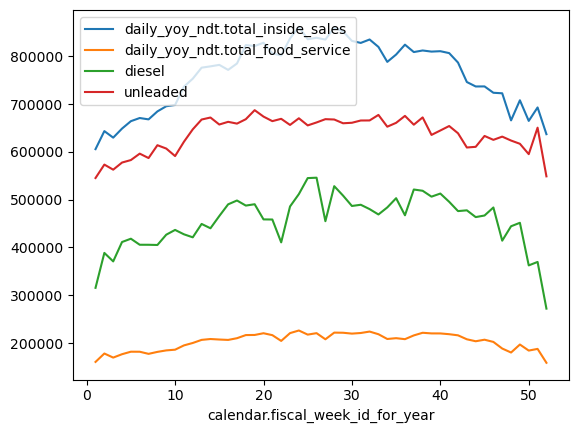

```python
plt.figure(figsize=(40, 50));
df_time_aggregate.plot();
```

### 4.1.4 Identifying Sale of Diesel and Unleaded during Weekend and Weekdays of the years 2021, 2022, 2023

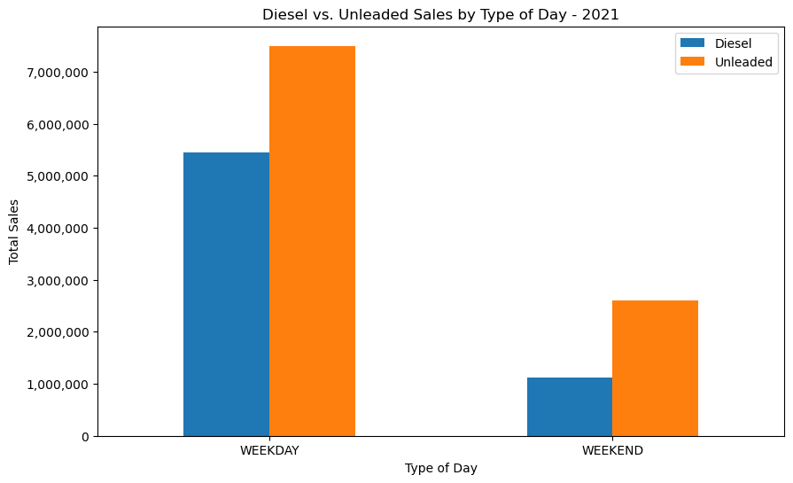

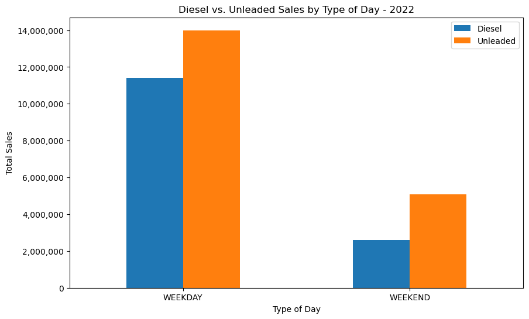

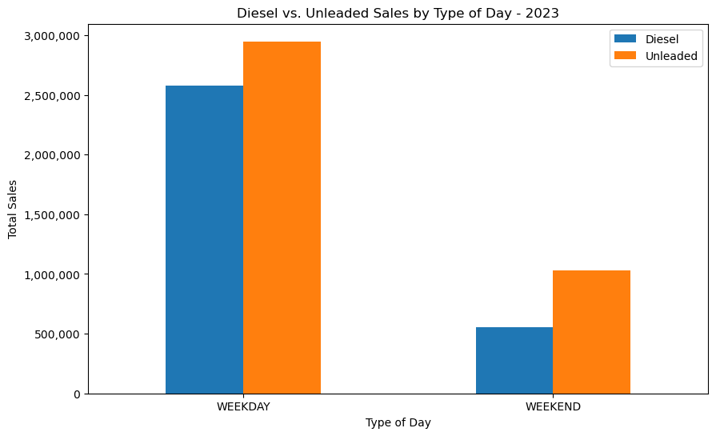

```python
for year in [2021, 2022, 2023]:
    sales_year = t_data[t_data['calendar_year'] == year]
    pivot_table = sales_year.pivot_table(index='calendar_information.type_of_day',
                                         values=['diesel', 'unleaded'],
                                         aggfunc='sum')
    ax = pivot_table.plot(kind='bar', figsize=(10, 6))
    plt.title(f'Diesel vs. Unleaded Sales by Type of Day - {year}')
    plt.xlabel('Type of Day')
    plt.ylabel('Total Sales')
    ax.yaxis.set_major_formatter(mtick.FuncFormatter(lambda x, p: format(int(x), ',')))
    ax.set_xticklabels(pivot_table.index, rotation=0)

    plt.legend(['Diesel', 'Unleaded'])
    plt.show()
```

### 4.1.5 Identifying Sale of Merchandise and Food during Weekend and Weekdays for the years 2021,2022,2023

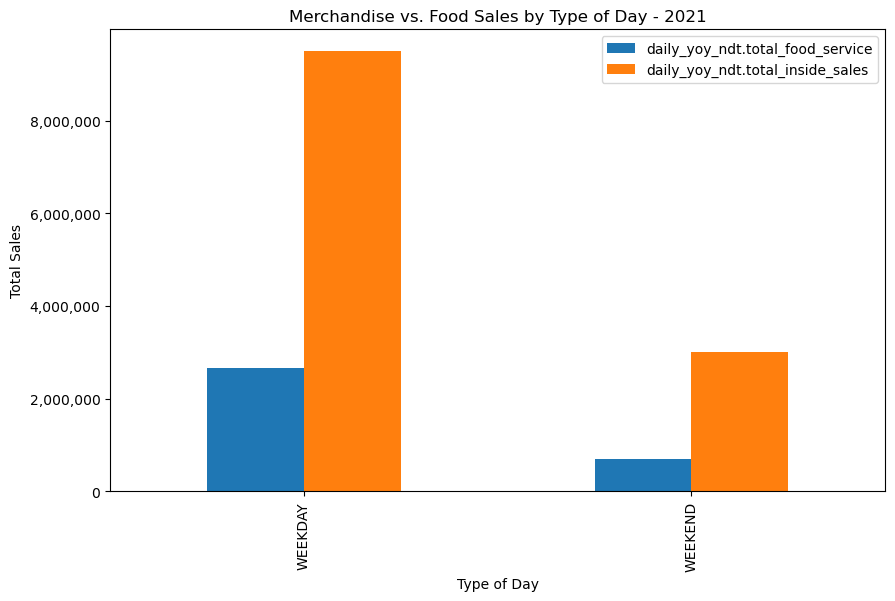

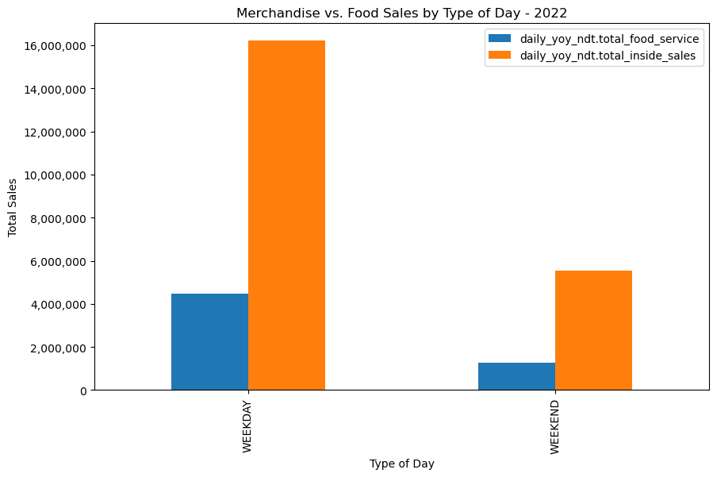

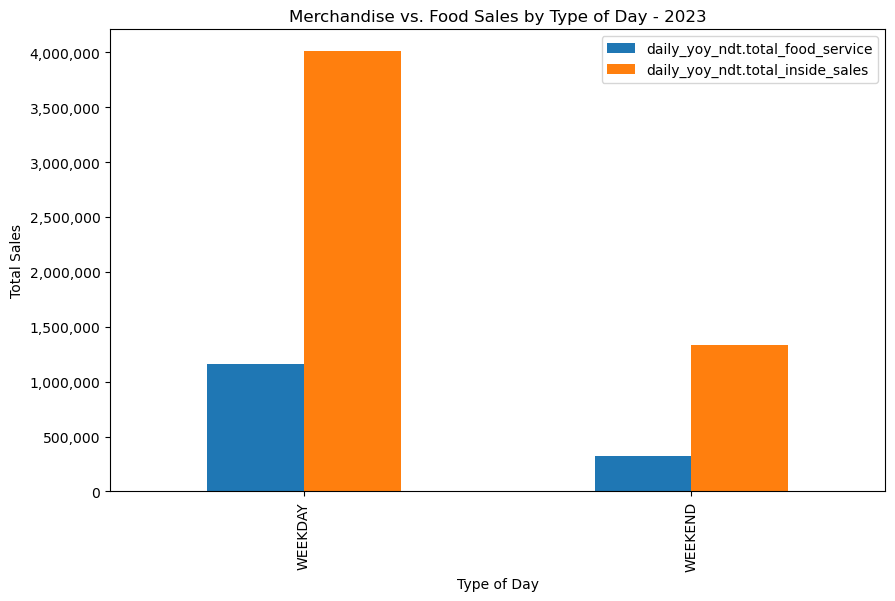

```python
for year in [2021, 2022, 2023]:
    sales_year = t_data[t_data['calendar_year'] == year]
    pivot_table = sales_year.pivot_table(index='calendar_information.type_of_day',
                                         values=['daily_yoy_ndt.total_inside_sales', 'daily_yoy_ndt.total_food_service'],
                                         aggfunc='sum')
    ax = pivot_table.plot(kind='bar', figsize=(10, 6))
    plt.title(f'Merchandise vs. Food Sales by Type of Day - {year}')
    plt.xlabel('Type of Day')
    plt.ylabel('Total Sales')
    ax.yaxis.set_major_formatter(mtick.FuncFormatter(lambda x, p: format(int(x), ',')))
```

### 4.1.6 Plotting diesel and unleaded sales on Holidays for the year 2021,2022 and 2023

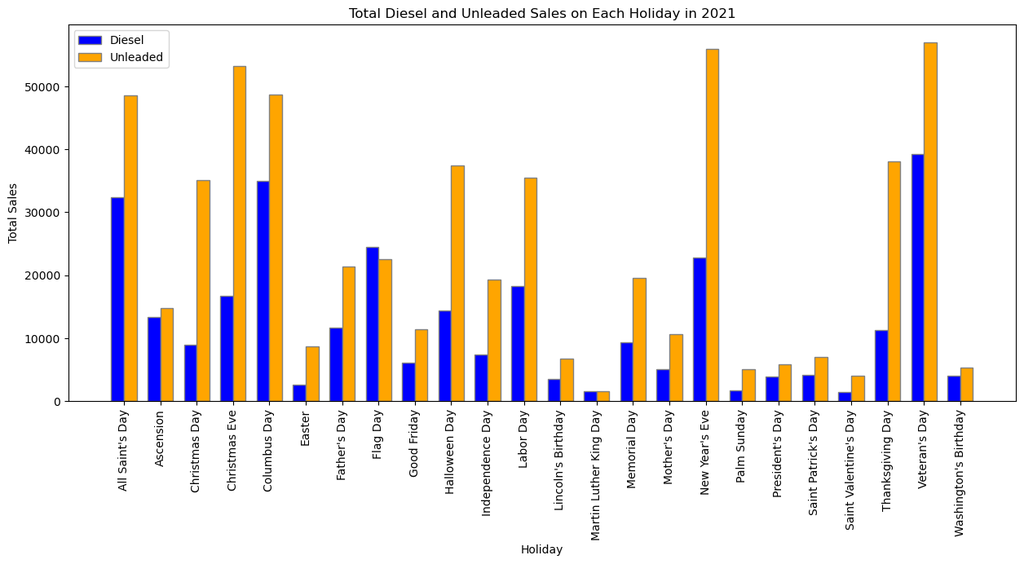

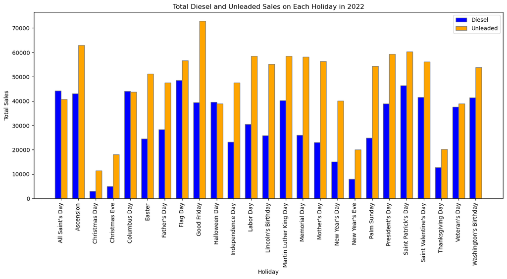

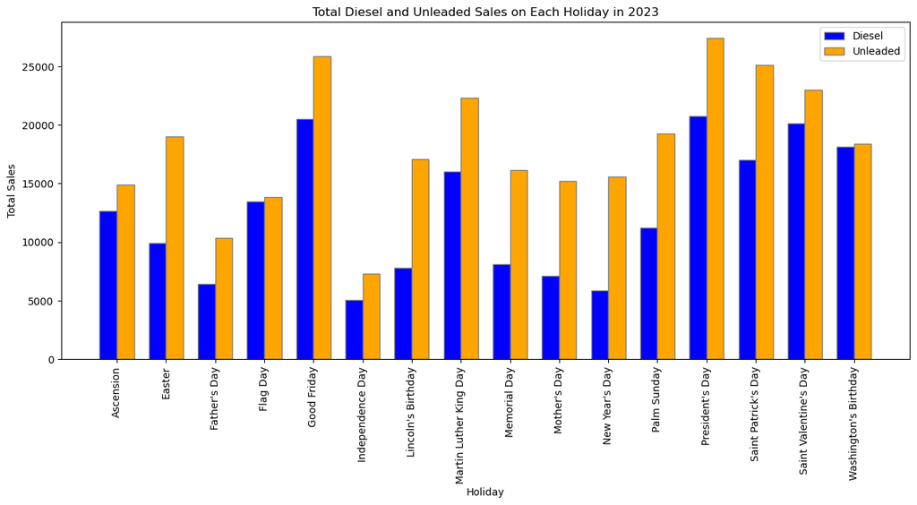

```python
#2021
t_data_2021 = t_data[t_data['calendar_year'] == 2021]
sales_by_holiday_2021 = t_data_2021.groupby('calendar_information.holiday')[['diesel', 'unleaded']].sum()
sales_by_holiday_2021 = sales_by_holiday_2021[sales_by_holiday_2021.index != 'NONE']
holidays_2021 = sales_by_holiday_2021.index.tolist()
diesel_sales_2021 = sales_by_holiday_2021['diesel'].tolist()
unleaded_sales_2021 = sales_by_holiday_2021['unleaded'].tolist()

plt.figure(figsize=(15, 6))
bar_width = 0.35
r1 = range(len(holidays_2021))
r2 = [x + bar_width for x in r1]
plt.bar(r1, diesel_sales_2021, color='blue', width=bar_width, edgecolor='grey', label='Diesel')
plt.bar(r2, unleaded_sales_2021, color='orange', width=bar_width, edgecolor='grey', label='Unleaded')
plt.xlabel('Holiday')
plt.ylabel('Total Sales')
plt.title('Total Diesel and Unleaded Sales on Each Holiday in 2021')
plt.xticks([r + bar_width/2 for r in r1], holidays_2021, rotation=90)
plt.legend()
plt.show()

#2022
t_data_2022 = t_data[t_data['calendar_year'] == 2022]
sales_by_holiday_2022 = t_data_2022.groupby('calendar_information.holiday')[['diesel', 'unleaded']].sum()
sales_by_holiday_2022 = sales_by_holiday_2022[sales_by_holiday_2022.index != 'NONE']
holidays_2022 = sales_by_holiday_2022.index.tolist()
diesel_sales_2022 = sales_by_holiday_2022['diesel'].tolist()
unleaded_sales_2022 = sales_by_holiday_2022['unleaded'].tolist()

plt.figure(figsize=(15, 6))
bar_width = 0.35
r1 = range(len(holidays_2022))
r2 = [x + bar_width for x in r1]
plt.bar(r1, diesel_sales_2022, color='blue', width=bar_width, edgecolor='grey', label='Diesel')
plt.bar(r2, unleaded_sales_2022, color='orange', width=bar_width, edgecolor='grey', label='Unleaded')
plt.xlabel('Holiday')
plt.ylabel('Total Sales')
plt.title('Total Diesel and Unleaded Sales on Each Holiday in 2022')
plt.xticks([r + bar_width/2 for r in r1], holidays_2022, rotation=90)
plt.legend()
plt.show()

#2023
t_data_2023 = t_data[t_data['calendar_year'] == 2023]
sales_by_holiday_2023 = t_data_2023.groupby('calendar_information.holiday')[['diesel', 'unleaded']].sum()
sales_by_holiday_2023 = sales_by_holiday_2023[sales_by_holiday_2023.index != 'NONE']
holidays_2023 = sales_by_holiday_2023.index.tolist()
diesel_sales_2023 = sales_by_holiday_2023['diesel'].tolist()
unleaded_sales_2023 = sales_by_holiday_2023['unleaded'].tolist()

plt.figure(figsize=(15, 6))
bar_width = 0.35
r1 = range(len(holidays_2023))
r2 = [x + bar_width for x in r1]
plt.bar(r1, diesel_sales_2023, color='blue', width=bar_width, edgecolor='grey', label='Diesel')
plt.bar(r2, unleaded_sales_2023, color='orange', width=bar_width, edgecolor='grey', label='Unleaded')
plt.xlabel('Holiday')
plt.ylabel('Total Sales')
plt.title('Total Diesel and Unleaded Sales on Each Holiday in 2023')
plt.xticks([r + bar_width/2 for r in r1], holidays_2023, rotation=90)
plt.legend()
plt.show()
```

### 4.1.7 Plotting in store and food sales on Holidays for the year 2021,2022 and 2023

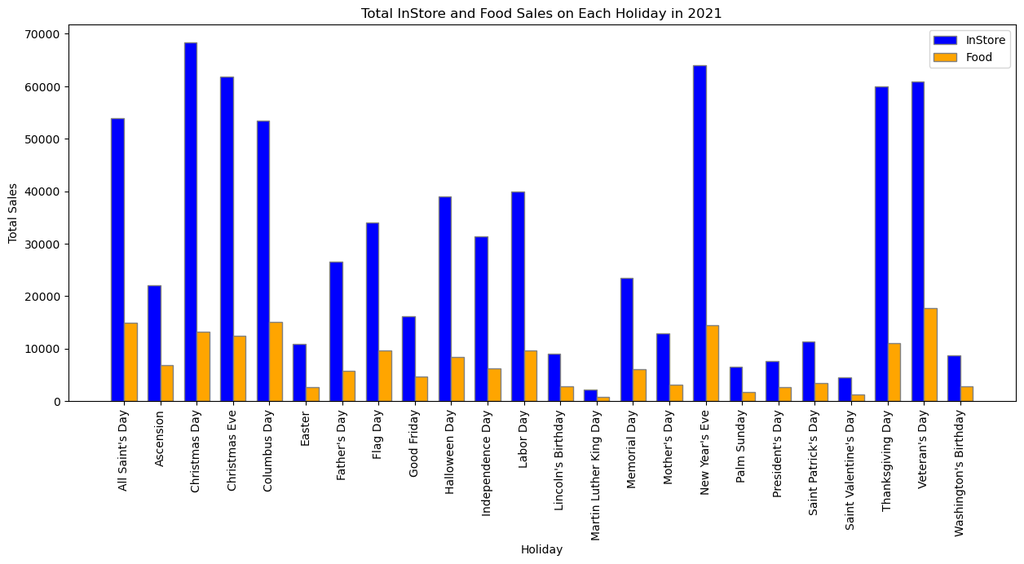

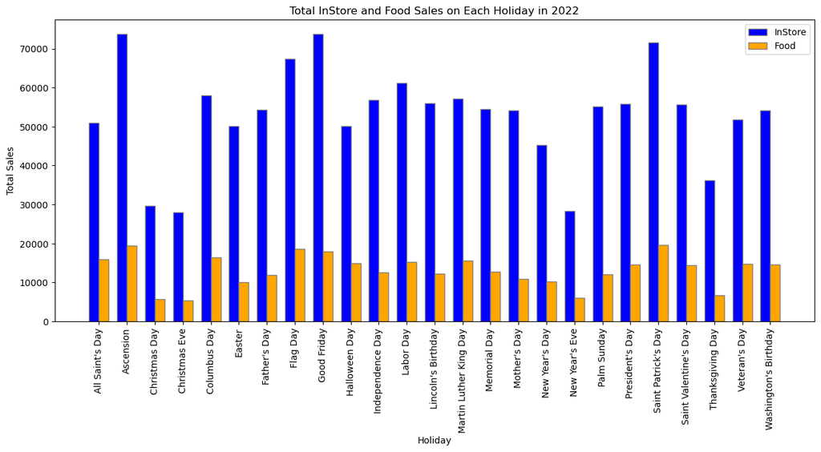

[figure not shown]

```python
#2021
t_data_2021 = t_data[t_data['calendar_year'] == 2021]
sales_by_holiday_2021 = t_data_2021.groupby('calendar_information.holiday')[['daily_yoy_ndt.total_inside_sales', 'daily_yoy_ndt.total_food_service']].sum()
sales_by_holiday_2021 = sales_by_holiday_2021[sales_by_holiday_2021.index != 'NONE']
holidays_2021 = sales_by_holiday_2021.index.tolist()
inStore_sales_2021 = sales_by_holiday_2021['daily_yoy_ndt.total_inside_sales'].tolist()
Food_sales_2021 = sales_by_holiday_2021['daily_yoy_ndt.total_food_service'].tolist()

plt.figure(figsize=(15, 6))
bar_width = 0.35
r1 = range(len(holidays_2021))
r2 = [x + bar_width for x in r1]
plt.bar(r1, inStore_sales_2021, color='blue', width=bar_width, edgecolor='grey', label='InStore')
plt.bar(r2, Food_sales_2021, color='orange', width=bar_width, edgecolor='grey', label='Food')
plt.xlabel('Holiday')
plt.ylabel('Total Sales')
plt.title('Total InStore and Food Sales on Each Holiday in 2021')
plt.xticks([r + bar_width/2 for r in r1], holidays_2021, rotation=90)
plt.legend()
plt.show()

#2022
t_data_2022 = t_data[t_data['calendar_year'] == 2022]
sales_by_holiday_2022 = t_data_2022.groupby('calendar_information.holiday')[['daily_yoy_ndt.total_inside_sales', 'daily_yoy_ndt.total_food_service']].sum()
sales_by_holiday_2022 = sales_by_holiday_2022[sales_by_holiday_2022.index != 'NONE']
holidays_2022 = sales_by_holiday_2022.index.tolist()
inStore_sales_2022 = sales_by_holiday_2022['daily_yoy_ndt.total_inside_sales'].tolist()
Food_sales_2022 = sales_by_holiday_2022['daily_yoy_ndt.total_food_service'].tolist()

plt.figure(figsize=(15, 6))
bar_width = 0.35
r1 = range(len(holidays_2022))
r2 = [x + bar_width for x in r1]
plt.bar(r1, inStore_sales_2022, color='blue', width=bar_width, edgecolor='grey', label='InStore')
plt.bar(r2, Food_sales_2022, color='orange', width=bar_width, edgecolor='grey', label='Food')
plt.xlabel('Holiday')
plt.ylabel('Total Sales')
plt.title('Total InStore and Food Sales on Each Holiday in 2022')
plt.xticks([r + bar_width/2 for r in r1], holidays_2022, rotation=90)
plt.legend()
plt.show()

#2023
t_data_2023 = t_data[t_data['calendar_year'] == 2023]
sales_by_holiday_2023 = t_data_2023.groupby('calendar_information.holiday')[['daily_yoy_ndt.total_inside_sales', 'daily_yoy_ndt.total_food_service']].sum()
sales_by_holiday_2023 = sales_by_holiday_2023[sales_by_holiday_2023.index != 'NONE']
holidays_2023 = sales_by_holiday_2023.index.tolist()
inStore_sales_2023 = sales_by_holiday_2023['daily_yoy_ndt.total_inside_sales'].tolist()
Food_sales_2023 = sales_by_holiday_2023['daily_yoy_ndt.total_food_service'].tolist()

plt.figure(figsize=(15, 6))
bar_width = 0.35
r1 = range(len(holidays_2023))
r2 = [x + bar_width for x in r1]
plt.bar(r1, inStore_sales_2023, color='blue', width=bar_width, edgecolor='grey', label='InStore')
plt.bar(r2, Food_sales_2023, color='orange', width=bar_width, edgecolor='grey', label='Food')
plt.xlabel('Holiday')
plt.ylabel('Total Sales')
plt.title('Total InStore and Food Sales on Each Holiday in 2021')
plt.xticks([r + bar_width/2 for r in r1], holidays_2023, rotation=90)
plt.legend()
plt.show()
```

##### The above graphs shows that the sale of In-store merchandise is more than the sale of food during Holidays.

### 4.1.8 Plotting In Store and food sales of Maverik store during each month of the year 2021,2022 and 2023

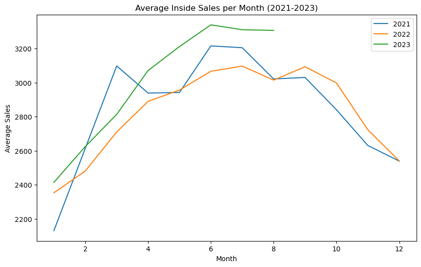

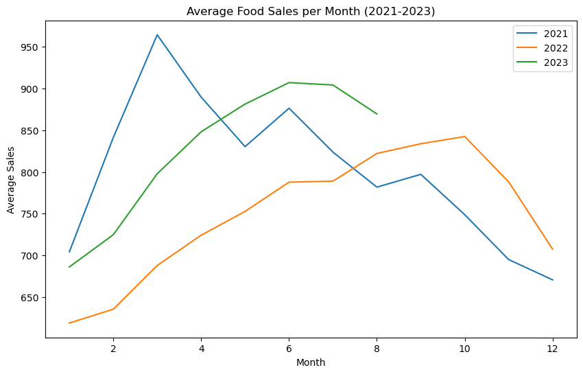

```python
average_sales_2021 = t_data_2021.groupby('calendar_month')['daily_yoy_ndt.total_inside_sales'].mean()
average_sales_2022 = t_data_2022.groupby('calendar_month')['daily_yoy_ndt.total_inside_sales'].mean()
average_sales_2023 = t_data_2023.groupby('calendar_month')['daily_yoy_ndt.total_inside_sales'].mean()
months = range(1,13)
months_2023 = range(1, 9)

plt.figure(figsize=(10, 6))

plt.plot(months, average_sales_2021, label='2021')
plt.plot(months, average_sales_2022, label='2022')
plt.plot(months_2023, average_sales_2023, label='2023')

plt.xlabel('Month')
plt.ylabel('Average Sales')
plt.title('Average Inside Sales per Month (2021-2023)')
plt.legend()
plt.show()



average_sales_2021 = t_data_2021.groupby('calendar_month')['daily_yoy_ndt.total_food_service'].mean()
average_sales_2022 = t_data_2022.groupby('calendar_month')['daily_yoy_ndt.total_food_service'].mean()
average_sales_2023 = t_data_2023.groupby('calendar_month')['daily_yoy_ndt.total_food_service'].mean()

months_2023 = range(1, 9)

plt.figure(figsize=(10, 6))

plt.plot(months, average_sales_2021, label='2021')
plt.plot(months, average_sales_2022, label='2022')
plt.plot(months_2023, average_sales_2023, label='2023')

plt.xlabel('Month')
plt.ylabel('Average Sales')
plt.title('Average Food Sales per Month (2021-2023)')
plt.legend()
plt.show()
```

### 4.1.9 Plotting Diesel and Unleaded sales of Maverik store during each month of the year 2021,2022 and 2023

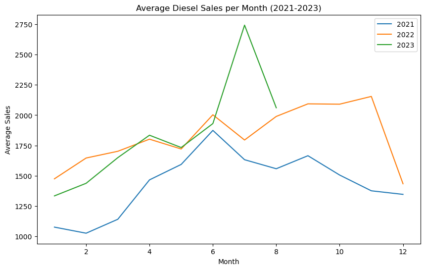

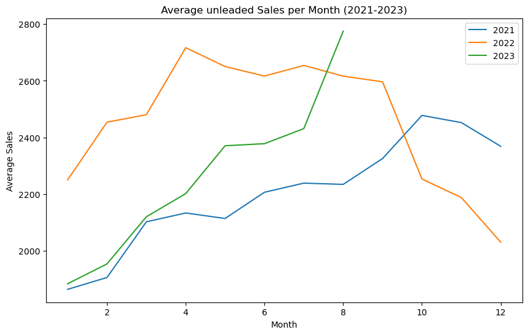

```python
average_sales_2021 = t_data_2021.groupby('calendar_month')['diesel'].mean()
average_sales_2022 = t_data_2022.groupby('calendar_month')['diesel'].mean()
average_sales_2023 = t_data_2023.groupby('calendar_month')['diesel'].mean()

months_2023 = range(1, 9)

plt.figure(figsize=(10, 6))

plt.plot(months, average_sales_2021, label='2021')
plt.plot(months, average_sales_2022, label='2022')
plt.plot(months_2023, average_sales_2023, label='2023')

plt.xlabel('Month')
plt.ylabel('Average Sales')
plt.title('Average Diesel Sales per Month (2021-2023)')
plt.legend()
plt.show()



average_sales_2021 = t_data_2021.groupby('calendar_month')['unleaded'].mean()
average_sales_2022 = t_data_2022.groupby('calendar_month')['unleaded'].mean()
average_sales_2023 = t_data_2023.groupby('calendar_month')['unleaded'].mean()

months_2023 = range(1, 9)

plt.figure(figsize=(10, 6))

plt.plot(months, average_sales_2021, label='2021')
plt.plot(months, average_sales_2022, label='2022')
plt.plot(months_2023, average_sales_2023, label='2023')

plt.xlabel('Month')
plt.ylabel('Average Sales')
plt.title('Average unleaded Sales per Month (2021-2023)')
plt.legend()
plt.show()
```

### 4.2.0 Inside and Food Sales based on Seasonality

```
Inside Sales for 2021:
```

|  | Season | Total Sales (2021) |
| --- | --- | --- |
| 0 | Fall | 4,965,353.13 |
| 1 | Spring | 1,479,716.70 |
| 2 | Summer | 3,803,032.47 |
| 3 | Winter | 2,255,542.94 |

```
 Inside Sales for 2022:
```

|  | Season | Total Sales (2022) |
| --- | --- | --- |
| 0 | Fall | 5,030,273.83 |
| 1 | Spring | 6,130,527.21 |
| 2 | Summer | 6,121,676.82 |
| 3 | Winter | 4,458,846.58 |

```
 Inside Sales for 2023:
```

|  | Season | Total Sales (2023) |
| --- | --- | --- |
| 0 | Spring | 2,586,886.73 |
| 1 | Summer | 977,866.26 |
| 2 | Winter | 1,779,927.67 |

```
Food Sales for 2021:
```

|  | Season | Total Sales (2021) |
| --- | --- | --- |
| 0 | Fall | 1,309,059.60 |
| 1 | Spring | 436,452.34 |
| 2 | Summer | 996,153.76 |
| 3 | Winter | 611,970.67 |

```
 Food Sales for 2022:
```

|  | Season | Total Sales (2022) |
| --- | --- | --- |
| 0 | Fall | 1,401,922.47 |
| 1 | Spring | 1,551,493.74 |
| 2 | Summer | 1,600,273.02 |
| 3 | Winter | 1,177,648.00 |

```
 Food Sales for 2023:
```

|  | Season | Total Sales (2023) |
| --- | --- | --- |
| 0 | Spring | 719,865.86 |
| 1 | Summer | 265,347.58 |
| 2 | Winter | 498,812.66 |

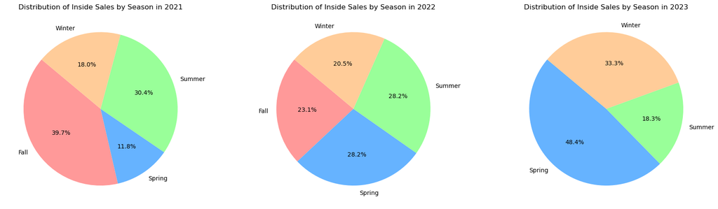

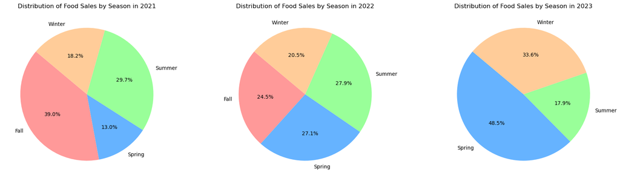

```python
def get_season(month):
    if month in [12, 1, 2]:
        return 'Winter'
    elif month in [3, 4, 5]:
        return 'Spring'
    elif month in [6, 7, 8]:
        return 'Summer'
    else:
        return 'Fall'


t_data['season'] = t_data['calendar_month'].apply(get_season)


t_data_2021 = t_data[t_data['calendar_year'] == 2021].copy()


t_data_2022 = t_data[t_data['calendar_year'] == 2022].copy()


t_data_2023 = t_data[t_data['calendar_year'] == 2023].copy()

sales_by_season_2021 = t_data_2021.groupby('season')[['daily_yoy_ndt.total_inside_sales']].sum()


sales_by_season_2022 = t_data_2022.groupby('season')[['daily_yoy_ndt.total_inside_sales']].sum()


sales_by_season_2023 = t_data_2023.groupby('season')[['daily_yoy_ndt.total_inside_sales']].sum()


plt.figure(figsize=(18, 5))


plt.subplot(1, 3, 1)
plt.pie(sales_by_season_2021['daily_yoy_ndt.total_inside_sales'], labels=sales_by_season_2021.index, autopct='%1.1f%%', startangle=140, colors=['#ff9999','#66b3ff','#99ff99','#ffcc99'])
plt.title('Distribution of Inside Sales by Season in 2021')

plt.subplot(1, 3, 2)
plt.pie(sales_by_season_2022['daily_yoy_ndt.total_inside_sales'], labels=sales_by_season_2022.index, autopct='%1.1f%%', startangle=140, colors=['#ff9999','#66b3ff','#99ff99','#ffcc99'])
plt.title('Distribution of Inside Sales by Season in 2022')


plt.subplot(1, 3, 3)
plt.pie(sales_by_season_2023['daily_yoy_ndt.total_inside_sales'], labels=sales_by_season_2023.index, autopct='%1.1f%%', startangle=140, colors=['#66b3ff','#99ff99','#ffcc99'])
plt.title('Distribution of Inside Sales by Season in 2023')

plt.tight_layout()


sales_table_2021 = sales_by_season_2021.reset_index()
sales_table_2021.columns = ['Season', 'Total Sales (2021)']


sales_table_2022 = sales_by_season_2022.reset_index()
sales_table_2022.columns = ['Season', 'Total Sales (2022)']


sales_table_2023 = sales_by_season_2023.reset_index()
sales_table_2023.columns = ['Season', 'Total Sales (2023)']


with pd.option_context('display.float_format', '{:,.2f}'.format):
    print("Inside Sales for 2021:")
    display(sales_table_2021)
    print("\n Inside Sales for 2022:")
    display(sales_table_2022)
    print("\n Inside Sales for 2023:")
    display(sales_table_2023)

t_data['season'] = t_data['calendar_month'].apply(get_season)


t_data_2021 = t_data[t_data['calendar_year'] == 2021].copy()

t_data_2022 = t_data[t_data['calendar_year'] == 2022].copy()


t_data_2023 = t_data[t_data['calendar_year'] == 2023].copy()

sales_by_season_2021 = t_data_2021.groupby('season')[['daily_yoy_ndt.total_food_service']].sum()


sales_by_season_2022 = t_data_2022.groupby('season')[['daily_yoy_ndt.total_food_service']].sum()


sales_by_season_2023 = t_data_2023.groupby('season')[['daily_yoy_ndt.total_food_service']].sum()

plt.figure(figsize=(18, 5))

plt.subplot(1, 3, 1)
plt.pie(sales_by_season_2021['daily_yoy_ndt.total_food_service'], labels=sales_by_season_2021.index, autopct='%1.1f%%', startangle=140, colors=['#ff9999','#66b3ff','#99ff99','#ffcc99'])
plt.title('Distribution of Food Sales by Season in 2021')

plt.subplot(1, 3, 2)
plt.pie(sales_by_season_2022['daily_yoy_ndt.total_food_service'], labels=sales_by_season_2022.index, autopct='%1.1f%%', startangle=140, colors=['#ff9999','#66b3ff','#99ff99','#ffcc99'])
plt.title('Distribution of Food Sales by Season in 2022')

plt.subplot(1, 3, 3)
plt.pie(sales_by_season_2023['daily_yoy_ndt.total_food_service'], labels=sales_by_season_2023.index, autopct='%1.1f%%', startangle=140, colors=['#66b3ff','#99ff99','#ffcc99'])
plt.title('Distribution of Food Sales by Season in 2023')

plt.tight_layout()


sales_table_2021 = sales_by_season_2021.reset_index()
sales_table_2021.columns = ['Season', 'Total Sales (2021)']


sales_table_2022 = sales_by_season_2022.reset_index()
sales_table_2022.columns = ['Season', 'Total Sales (2022)']

sales_table_2023 = sales_by_season_2023.reset_index()
sales_table_2023.columns = ['Season', 'Total Sales (2023)']

with pd.option_context('display.float_format', '{:,.2f}'.format):
    print("Food Sales for 2021:")
    display(sales_table_2021)
    print("\n Food Sales for 2022:")
    display(sales_table_2022)
    print("\n Food Sales for 2023:")
    display(sales_table_2023)
```

### 4.2.1 Diesel and Unleaded Sales based on Seasonality

```
Sales for 2021:
```

|  | Season | Total Sales (2021) |
| --- | --- | --- |
| 0 | Fall | 2,650,068.48 |
| 1 | Spring | 728,384.00 |
| 2 | Summer | 2,023,123.50 |
| 3 | Winter | 1,165,056.13 |

```
Sales for 2022:
```

|  | Season | Total Sales (2022) |
| --- | --- | --- |
| 0 | Fall | 3,590,740.64 |
| 1 | Spring | 3,743,812.36 |
| 2 | Summer | 3,859,752.97 |
| 3 | Winter | 2,790,836.70 |

```
Sales for 2023:
```

|  | Season | Total Sales (2023) |
| --- | --- | --- |
| 0 | Spring | 1,491,919.96 |
| 1 | Summer | 656,316.77 |
| 2 | Winter | 979,543.83 |

```
Sales for 2021:
```

|  | Season | Total Sales (2021) |
| --- | --- | --- |
| 0 | Fall | 4,275,515.47 |
| 1 | Spring | 1,055,160.85 |
| 2 | Summer | 2,703,529.66 |
| 3 | Winter | 2,056,975.09 |

```
Sales for 2022:
```

|  | Season | Total Sales (2022) |
| --- | --- | --- |
| 0 | Fall | 4,023,479.15 |
| 1 | Spring | 5,619,266.38 |
| 2 | Summer | 5,260,911.29 |
| 3 | Winter | 4,157,802.81 |

```
Sales for 2023:
```

|  | Season | Total Sales (2023) |
| --- | --- | --- |
| 0 | Spring | 1,904,366.26 |
| 1 | Summer | 715,509.25 |
| 2 | Winter | 1,357,613.57 |

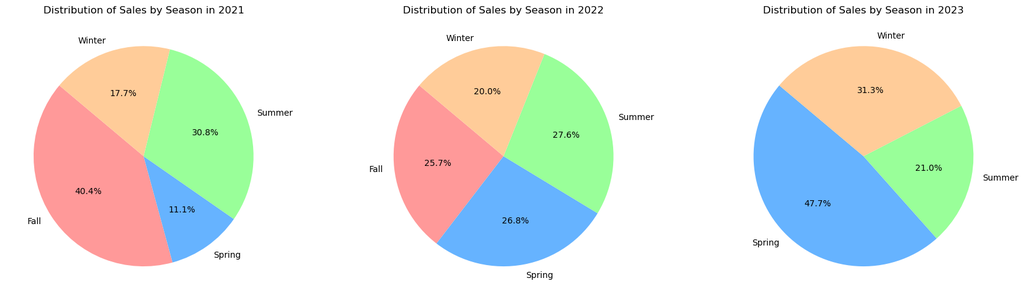

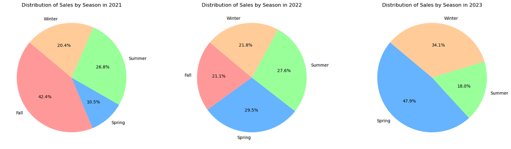

```python
def get_season(month):
    if month in [12, 1, 2]:
        return 'Winter'
    elif month in [3, 4, 5]:
        return 'Spring'
    elif month in [6, 7, 8]:
        return 'Summer'
    else:
        return 'Fall'


t_data['season'] = t_data['calendar_month'].apply(get_season)


t_data_2021 = t_data[t_data['calendar_year'] == 2021].copy()


t_data_2022 = t_data[t_data['calendar_year'] == 2022].copy()


t_data_2023 = t_data[t_data['calendar_year'] == 2023].copy()


sales_by_season_2021 = t_data_2021.groupby('season')[['diesel']].sum()

sales_by_season_2022 = t_data_2022.groupby('season')[['diesel']].sum()

sales_by_season_2023 = t_data_2023.groupby('season')[['diesel']].sum()

plt.figure(figsize=(18, 5))


plt.subplot(1, 3, 1)
plt.pie(sales_by_season_2021['diesel'], labels=sales_by_season_2021.index, autopct='%1.1f%%', startangle=140, colors=['#ff9999','#66b3ff','#99ff99','#ffcc99'])
plt.title('Distribution of Sales by Season in 2021')


plt.subplot(1, 3, 2)
plt.pie(sales_by_season_2022['diesel'], labels=sales_by_season_2022.index, autopct='%1.1f%%', startangle=140, colors=['#ff9999','#66b3ff','#99ff99','#ffcc99'])
plt.title('Distribution of Sales by Season in 2022')

plt.subplot(1, 3, 3)
plt.pie(sales_by_season_2023['diesel'], labels=sales_by_season_2023.index, autopct='%1.1f%%', startangle=140, colors=['#66b3ff','#99ff99','#ffcc99'])
plt.title('Distribution of Sales by Season in 2023')

plt.tight_layout()


sales_table_2021 = sales_by_season_2021.reset_index()
sales_table_2021.columns = ['Season', 'Total Sales (2021)']


sales_table_2022 = sales_by_season_2022.reset_index()
sales_table_2022.columns = ['Season', 'Total Sales (2022)']


sales_table_2023 = sales_by_season_2023.reset_index()
sales_table_2023.columns = ['Season', 'Total Sales (2023)']


with pd.option_context('display.float_format', '{:,.2f}'.format):
    print("Sales for 2021:")
    display(sales_table_2021)
    print("\nSales for 2022:")
    display(sales_table_2022)
    print("\nSales for 2023:")
    display(sales_table_2023)


t_data['season'] = t_data['calendar_month'].apply(get_season)


t_data_2021 = t_data[t_data['calendar_year'] == 2021].copy()


t_data_2022 = t_data[t_data['calendar_year'] == 2022].copy()


t_data_2023 = t_data[t_data['calendar_year'] == 2023].copy()


sales_by_season_2021 = t_data_2021.groupby('season')[['unleaded']].sum()


sales_by_season_2022 = t_data_2022.groupby('season')[['unleaded']].sum()


sales_by_season_2023 = t_data_2023.groupby('season')[['unleaded']].sum()


plt.figure(figsize=(18, 5))


plt.subplot(1, 3, 1)
plt.pie(sales_by_season_2021['unleaded'], labels=sales_by_season_2021.index, autopct='%1.1f%%', startangle=140, colors=['#ff9999','#66b3ff','#99ff99','#ffcc99'])
plt.title('Distribution of Sales by Season in 2021')

plt.subplot(1, 3, 2)
plt.pie(sales_by_season_2022['unleaded'], labels=sales_by_season_2022.index, autopct='%1.1f%%', startangle=140, colors=['#ff9999','#66b3ff','#99ff99','#ffcc99'])
plt.title('Distribution of Sales by Season in 2022')


plt.subplot(1, 3, 3)
plt.pie(sales_by_season_2023['unleaded'], labels=sales_by_season_2023.index, autopct='%1.1f%%', startangle=140, colors=['#66b3ff','#99ff99','#ffcc99'])
plt.title('Distribution of Sales by Season in 2023')

plt.tight_layout()


sales_table_2021 = sales_by_season_2021.reset_index()
sales_table_2021.columns = ['Season', 'Total Sales (2021)']


sales_table_2022 = sales_by_season_2022.reset_index()
sales_table_2022.columns = ['Season', 'Total Sales (2022)']


sales_table_2023 = sales_by_season_2023.reset_index()
sales_table_2023.columns = ['Season', 'Total Sales (2023)']


with pd.option_context('display.float_format', '{:,.2f}'.format):
    print("Sales for 2021:")
    display(sales_table_2021)
    print("\nSales for 2022:")
    display(sales_table_2022)
    print("\nSales for 2023:")
    display(sales_table_2023)
```

### 4.2.2 Total sale of target variables for all site id's

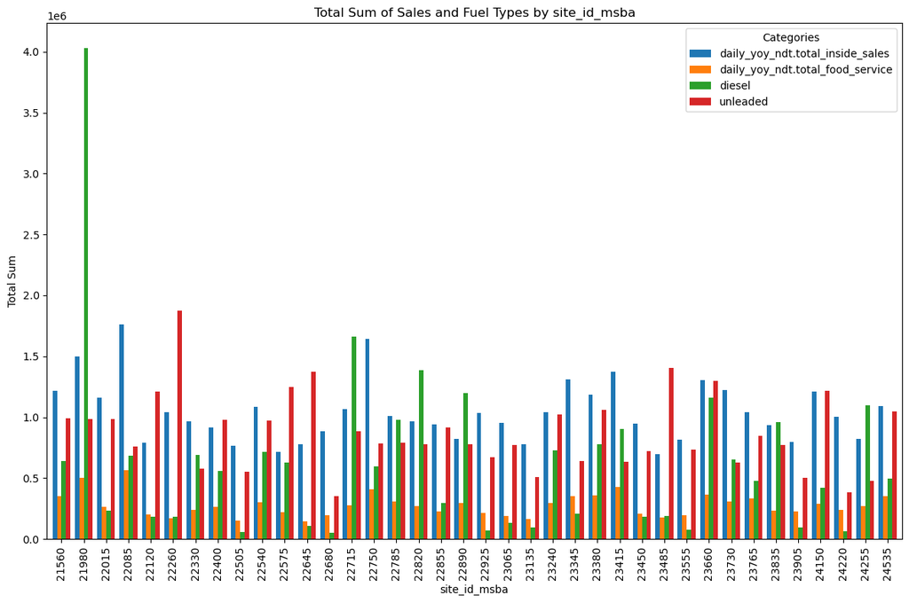

```python
grouped_data = t_data.groupby('site_id_msba').agg({
    'daily_yoy_ndt.total_inside_sales': 'sum',
    'daily_yoy_ndt.total_food_service': 'sum',
    'diesel': 'sum',
    'unleaded': 'sum'
}).reset_index()

grouped_data.set_index('site_id_msba', inplace=True)


ax = grouped_data.plot(kind='bar', figsize=(12, 8), width=0.8)
plt.xlabel('site_id_msba')
plt.ylabel('Total Sum')
plt.title('Total Sum of Sales and Fuel Types by site_id_msba')
plt.legend(title='Categories')


plt.tight_layout()
plt.show()
```

## 5. Merging both dataframes

```python
df_merged=pd.merge(t_data,q_data, on='site_id_msba', how='left')
```

```python
df_merged.shape
```

```
(13908, 60)
```

```python
df_merged.head()
```

|  | capital_projects.soft_opening_date | calendar.fiscal_week_id_for_year | calendar.day_of_week | calendar_information.holiday | calendar_information.type_of_day | daily_yoy_ndt.total_inside_sales | daily_yoy_ndt.total_food_service | diesel | unleaded | site_id_msba | ... | hi_flow_lanes_layout | hi_flow_lanes_stack_type | hi_flow_lanes_fueling_positions_2 | rv_lanes_fueling_positions_2 | hi_flow_rv_lanes_layout | hi_flow_rv_lanes_stack_type | mens_toilet_count | mens_urinal_count | womens_toilet_count | womens_sink_count |
| --- | --- | --- | --- | --- | --- | --- | --- | --- | --- | --- | --- | --- | --- | --- | --- | --- | --- | --- | --- | --- | --- |
| 0 | 2022-06-14 | 25 | Friday | NONE | WEEKDAY | 2168.2920 | 861.6930 | 722.7745 | 1425.1020 | 24535 | ... | 1.0 | 0.0 | 5.0 | 4.0 | 1.0 | 0.0 | 1.0 | 1.0 | 2.0 | 2.0 |
| 1 | 2022-06-14 | 25 | Wednesday | NONE | WEEKDAY | 2051.5635 | 808.0275 | 730.4850 | 1436.2740 | 24535 | ... | 1.0 | 0.0 | 5.0 | 4.0 | 1.0 | 0.0 | 1.0 | 1.0 | 2.0 | 2.0 |
| 2 | 2022-06-14 | 25 | Thursday | NONE | WEEKDAY | 2257.5000 | 966.4410 | 895.7970 | 1594.3725 | 24535 | ... | 1.0 | 0.0 | 5.0 | 4.0 | 1.0 | 0.0 | 1.0 | 1.0 | 2.0 | 2.0 |
| 3 | 2022-06-14 | 26 | Sunday | NONE | WEEKEND | 1520.5925 | 542.3250 | 584.2900 | 1124.9280 | 24535 | ... | 1.0 | 0.0 | 5.0 | 4.0 | 1.0 | 0.0 | 1.0 | 1.0 | 2.0 | 2.0 |
| 4 | 2022-06-14 | 26 | Monday | NONE | WEEKDAY | 1897.6930 | 771.4525 | 852.2605 | 1640.2540 | 24535 | ... | 1.0 | 0.0 | 5.0 | 4.0 | 1.0 | 0.0 | 1.0 | 1.0 | 2.0 | 2.0 |

5 rows × 60 columns

### 5.1 Relation between customer population and income

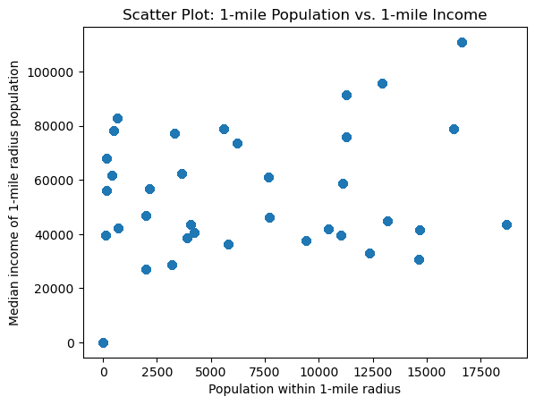

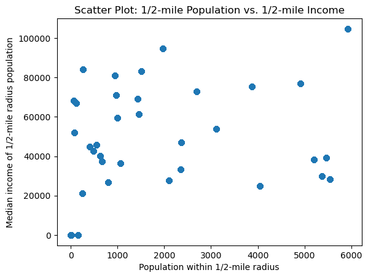

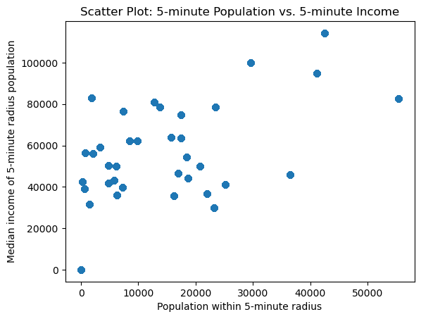

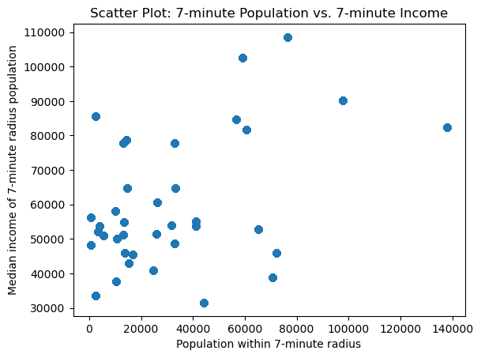

```python
plt.scatter(df_merged['x1_mile_pop'], df_merged['x1_mile_income'])
plt.xlabel('Population within 1-mile radius')
plt.ylabel('Median income of 1-mile radius population')
plt.title('Scatter Plot: 1-mile Population vs. 1-mile Income')
plt.show()

plt.scatter(df_merged['x1_2_mile_pop'], df_merged['x1_2_mile_income'])
plt.xlabel('Population within 1/2-mile radius')
plt.ylabel('Median income of 1/2-mile radius population')
plt.title('Scatter Plot: 1/2-mile Population vs. 1/2-mile Income')
plt.show()

plt.scatter(df_merged['x5_min_pop'], df_merged['x5_min_inc'])
plt.xlabel('Population within 5-minute radius')
plt.ylabel('Median income of 5-minute radius population')
plt.title('Scatter Plot: 5-minute Population vs. 5-minute Income')
plt.show()

plt.scatter(df_merged['x7_min_pop'], df_merged['x7_min_inc'])
plt.xlabel('Population within 7-minute radius')
plt.ylabel('Median income of 7-minute radius population')
plt.title('Scatter Plot: 7-minute Population vs. 7-minute Income')
plt.show()
```

### 5.2 Population in Miles vs Total Sales

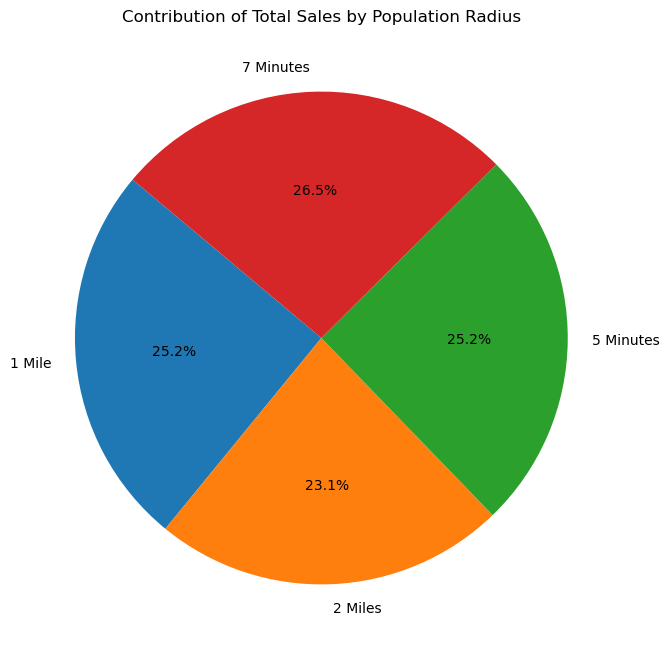

```python
df_merged['total_sales'] = df_merged['daily_yoy_ndt.total_food_service'] + df_merged['daily_yoy_ndt.total_inside_sales']
total_sales_1_mile = df_merged[df_merged['x1_mile_pop'] > 0]['total_sales'].sum()
total_sales_2_mile = df_merged[df_merged['x1_2_mile_pop'] > 0]['total_sales'].sum()
total_sales_5_min = df_merged[df_merged['x5_min_pop'] > 0]['total_sales'].sum()
total_sales_7_min = df_merged[df_merged['x7_min_pop'] > 0]['total_sales'].sum()


labels = ['1 Mile', '2 Miles', '5 Minutes', '7 Minutes']
values = [total_sales_1_mile, total_sales_2_mile, total_sales_5_min, total_sales_7_min]

plt.figure(figsize=(8, 8))
plt.pie(values, labels=labels, autopct='%1.1f%%', startangle=140)
plt.title('Contribution of Total Sales by Population Radius')
plt.show()
```

### 5.3 Customer Income vs Total Sales

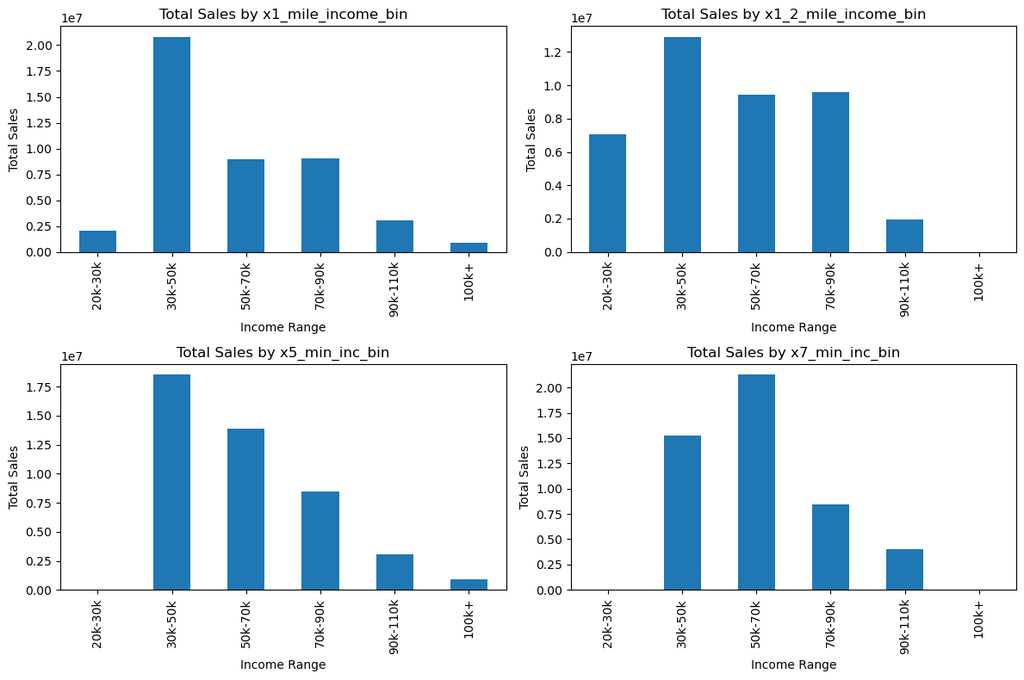

```python
income_bins = [20000, 30000, 50000, 70000, 90000, 110000, 1000000]
income_labels = ['20k-30k', '30k-50k', '50k-70k', '70k-90k', '90k-110k', '100k+']

df_merged['x1_mile_income_bin'] = pd.cut(df_merged['x1_mile_income'], bins=income_bins, labels=income_labels, right=False)
df_merged['x1_2_mile_income_bin'] = pd.cut(df_merged['x1_2_mile_income'], bins=income_bins, labels=income_labels, right=False)
df_merged['x5_min_inc_bin'] = pd.cut(df_merged['x5_min_inc'], bins=income_bins, labels=income_labels, right=False)
df_merged['x7_min_inc_bin'] = pd.cut(df_merged['x7_min_inc'], bins=income_bins, labels=income_labels, right=False)

df_merged['total_sales'] = df_merged['daily_yoy_ndt.total_inside_sales'] + df_merged['daily_yoy_ndt.total_food_service']


total_sales_by_income_x1_mile = df_merged.groupby('x1_mile_income_bin')['total_sales'].sum()
total_sales_by_income_x1_2_mile = df_merged.groupby('x1_2_mile_income_bin')['total_sales'].sum()
total_sales_by_income_x5_min = df_merged.groupby('x5_min_inc_bin')['total_sales'].sum()
total_sales_by_income_x7_min = df_merged.groupby('x7_min_inc_bin')['total_sales'].sum()

plt.figure(figsize=(12, 8))


plt.subplot(221)
total_sales_by_income_x1_mile.plot(kind='bar')
plt.title('Total Sales by x1_mile_income_bin')
plt.xlabel('Income Range')
plt.ylabel('Total Sales')


plt.subplot(222)
total_sales_by_income_x1_2_mile.plot(kind='bar')
plt.title('Total Sales by x1_2_mile_income_bin')
plt.xlabel('Income Range')
plt.ylabel('Total Sales')


plt.subplot(223)
total_sales_by_income_x5_min.plot(kind='bar')
plt.title('Total Sales by x5_min_inc_bin')
plt.xlabel('Income Range')
plt.ylabel('Total Sales')


plt.subplot(224)
total_sales_by_income_x7_min.plot(kind='bar')
plt.title('Total Sales by x7_min_inc_bin')
plt.xlabel('Income Range')
plt.ylabel('Total Sales')

plt.tight_layout()
plt.show()
```

### 5.4 Distribution of Sales based on Stores that Sell "freal," "bonfire_grill," "pizza," and "cinnabon"

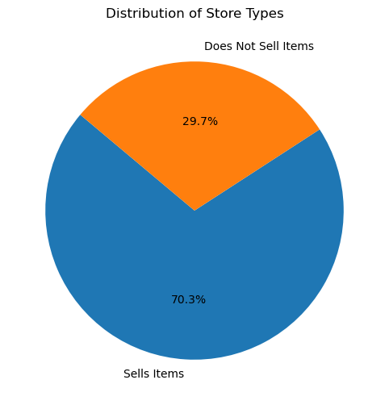

```python
sells_items = df_merged[(df_merged['freal'] > 0) | (df_merged['bonfire_grill'] > 0) | (df_merged['pizza'] > 0) | (df_merged['cinnabon'] > 0)]
does_not_sell_items = df_merged[(df_merged['freal'] == 0) & (df_merged['bonfire_grill'] == 0) & (df_merged['pizza'] == 0) & (df_merged['cinnabon'] == 0)]


avg_food_service_sells_items = sells_items['daily_yoy_ndt.total_food_service'].mean()
avg_food_service_does_not_sell_items = does_not_sell_items['daily_yoy_ndt.total_food_service'].mean()

store_type_counts = [len(sells_items), len(does_not_sell_items)]
labels = ['Sells Items', 'Does Not Sell Items']
plt.figure(figsize=(8, 6))
plt.pie(store_type_counts, labels=labels, autopct='%1.1f%%', startangle=140)
plt.title('Distribution of Store Types')
plt.show()
```